# Exploratory Analysis

## Match Point Metrics: Exploring Tennis Statistics

### Authors

Abigail Williams (aaw01@uw.edu)  
Madi Trimmer (mrtrimme@uw.edu)  
Stefan Cutovic (scuto26@uw.edu)

### Date

Spring 2024

### Abstract

We will consider the affects of various playing surfaces in tennis tournaments hosted by the Association of Tennis Professionals (ATP). Ivestigating this topic is important becuase we can potentially uncover hidden patterns and new avenues for optimizing player performance. Accordingly, we plan to identify trends, predict match outcomes, and deliver a comprehesnive summary of the factors influencing player success.

### Keywords

Association of Tennis Professionals, win rate, player ranking

### Introduction

> This project investigates the influence different playing surfaces has on player performance in the context of the Association of Tennis Professionals. Through our analysis we ask ourselves - is possible to predict the trajectory of a particular tennis player’s ranking based on historical data? This data will support statistics in match viewing popularity, player marketability, and tournament pools, all of which are integral to the tennis industry. Carefully applying these metrics to future events is likely to provide quality entertainment for the audience and increased revenue for the organization and or the individual player. Furthering the questions surrounding potential player success, we also wonder, how do the win rates of two tennis players, measured over a series of matches within a specific tournament, differ, and is there a significant variance in their performance? With this, we are able to evaluate relative strengths and abilities through win rates. Thus, allowing for direct comparisons between players, aiding in the assessment of their skill levels and competitiveness within the sport. Finally, and most importantly we want to know, Is there a statistically significant relationship between a tennis player’s performance and the type of surface they play on? Knowing this can contribute to answering our initial question surrounding player performance. If a player does particularly well on a specific surface we can use this as a parameter in considering a single match outcome between two opponents or an entire season for a single player.

### Related Work

> The rise of analytics and data-driven decision making has made significant progress into the world of professional tennis. While the sport has traditionally defied standard statistical analysis due to its unique scoring system, varied playing styles, and different court surfaces, the arrival of advanced analytics has opened up new modes of understanding player performance and developing match strategies. Major technology firms such as SAP and IBM have partnered with tours, tournaments, and players to provide detailed data analysis. Top players like Novak Djokovic and Roger Federer have both found their way into incorporating these techniques into their preparations. However, reactions from players remain mixed, with some cautiously assessing the value of analytics (Tandon).

> This shift towards data-driven approaches isn’t limited to professionals; organizations like the USTA (United States Tennis Association) have partnered with companies like Playisight to analyze youth players, identify talent, and optimize training programs using data on metrics like distance covered, intensity, and workload (Global Sport Matters). This allows coaches to mitigate injuries while simultaneously striving to enhance performance.

> Understanding the dynamics of ATP tennis tournaments can provide valuable insights into player performance and tournament organization. Analyzing historical tournament data allows us to identify trends, predict match outcomes, and gain a deeper understanding of the factors influencing player success (Wastcoat). While not a global problem per se, it would be interesting to see if data programming and analysis can provide answers to longstanding questions within the tennis community, such as the impact of surface preferences on performance or the significance of high win rates when predicting match outcomes. By using this data, we can potentially uncover hidden patterns and new avenues for optimizing player performance.

#### Works Cited –> (MLA, 8th ed.)

> Farrell, Sarah. “Tennis players embracing technology and analytics in training.” Global Sport Matters, 16 October 2019, https://globalsportmatters.com/science/2019/10/16/tennis-players-embracing-technology-analytics/. Accessed 30 April 2024.

> Tandon, Kamakshi. “The role of analytics in tennis is on a long, slow rise.” Tennis Channel, 17 January 2020, https://www.tennis.com/news/articles/the-role-of-analytics-in-tennis-is-on-a-long-slow-rise. Accessed 30 April 2024.

> Wastcoat, Eliza. “5 Exciting Ways AI Can Be Used In Tennis.” IoT For All, 20 June 2023, https://www.iotforall.com/5-exciting-ways-ai-can-be-used-in-tennis. Accessed 30 April 2024.

#### Links to Featured Sites:

> https://www.tennis.com/news/articles/the-role-of-analytics-in-tennis-is-on-a-long-slow-rise

> https://globalsportmatters.com/science/2019/10/16/tennis-players-embracing-technology-analytics/

> https://www.iotforall.com/5-exciting-ways-ai-can-be-used-in-tennis

### The Dataset

[Link to ATP Tennis 2013 - 2023](https://www.kaggle.com/datasets/dissfya/atp-tennis-2013-2023)

### Implications

> The analysis of ATP data carries significant implications that could shape the future of the sport and influence the various stakeholders involved in its ecosystem.

> For technologists, this study showcases the potential of data programming and analysis in uncovering valuable insights and patterns within the professional tour. With such findings, they can develop advanced analytics tools, predictive models, and data-driven decision support systems. These innovations could aid players, coaches, and tournament organizers in optimizing performance, strategy, and event planning (respectively), ultimately elevating the sport to new heights.

> Designers, too, benefit from this analysis, as it highlights the need for user-friendly and visually appealing data representations. By leveraging the insights gained, they can create intuitive visualizations and interfaces that effectively communicate complex statistical information to diverse audiences, including fans, players, coaches, and analysts.

> This could refine the overall experience and understanding of the sport for all stakeholders, while also potentially informing policymakers within the tennis industry. The findings related to players’ performance on different court surfaces could influence decisions regarding tournament scheduling, surface selections, or even rule modifications to improve fairness and competitiveness. This analysis could prompt broader discussions around data-driven decision-making in sports, athlete welfare, and the responsible use of analytics to maintain the integrity of the game.

### Limitations & Challenges

> While the project idea would showcase the potential of analytics within the sport of tennis, several challenges and limitations must be addressed to ensure its broader application and impact. For one, the plan heavily relies on the availability and quality of historical tournament data. Ensuring consistent, accurate, and comprehensive data collection across various tournaments, surfaces, and player demographics could be a significant challenge. Incomplete or inaccurate data could severely limit the scope and reliability of results derived, undermining the entire point of analysis.

> Furthermore, it’s important to consider the interpretability of statistical models and predictions made in the analysis. While these models can provide valuable insights, it’s crucial to ensure that the underlying assumptions, methodologies, and decision-making processes are transparent and easily interpretable. Failing to do so could result in widespread skepticism and distrust from stakeholders. Without clear explanations of how the analytics are derived and applied, there may be reluctance to adopt the insights and recommendations generated by the project.

> Lastly, while we’re projecting to perform various types of statistical models and analyses based on historical ATP data, our current knowledge may not be sufficient to bring those results to fruition effectively. Our goals within this project are tentative and subject to change based on our understanding of data programming and the complexity of the tasks involved. As we progress, we may discover that our initial objectives exceed our current skill level or require more advanced techniques than anticipated. In such cases, we will adapt our goals to better align with our capabilities. Addressing these challenges proactively is crucial for ensuring the responsible and effective application of data analytics in the tennis industry.

### Table

A table of aggregated data that looks at the average Ranks and Points score on each recorded tennis court surface

| Surface | Num_Matches | Avg_Rank1 | Avg_Rank2 | Avg_Points1 | Avg_Points2 |
| --- | --- | --- | --- | --- | --- |
| Hard | 14717 | 68.15 | 68.66 | 1651.25 | 1636.57 |
| Clay | 7656 | 78.97 | 77.12 | 1467.02 | 1457.35 |
| Grass | 2789 | 78.44 | 74.73 | 1473.63 | 1499.49 |

This table is important to understand in the context of this report because it demonstrates the general performance on and reputation of each court surface throughout the course of all recorded tennis matches. For instance, we can see that while a Hard surface is by far the most popular among all the observances, the players who play on it have the lowest rank. Meanwhile, Clay and Grass are played on fewer times; however players have a much higher rank on those surfaces. Therefore, it is logical to assume that the Clay and Grass surfaces might have a reputation of being harder to perform on, explaining both their lesser uses, as well as the high ranking of those who do play on them. This sentiment would also be supported by the fact that the average points on the latter surfaces are lower than that on a Hard surface. This information is especially interesting to note due to the context of our first Chart, which is looking at the court surface distribution by tournament series. In this sense, we can combine the information from both data visualizations and maybe gain insight into the reputation of a certain tournament and its players if they favor a particular court surface.

### Chart 1 - Court Surface Distribution Among Series

Using a multi-bar chart for this visualization was the most suitable choice as it allows for clear comparison of the number of matches played on each surface within each series. By having three differently colored bars for each series, viewers can easily discern the distribution of court surfaces across the different levels of tournaments that the ATP offers.

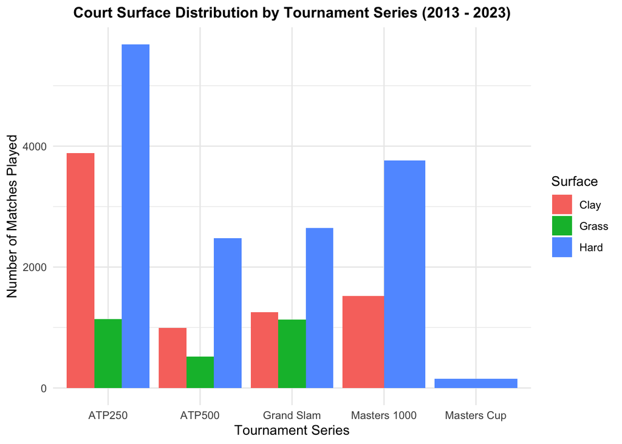

Based on the chart, it can seen that that the most prevalent surface across all series that’s played on is hard. The dominance of hard courts could be attributed to various factors, including their durability, lower maintenance costs compared to grass, and the consistency they offer in terms of ball bounce and playability, which makes them suitable for a broad range of playing styles. It can also be observed that Grass is the least prevalent type of surface played on, even being entirely nonexistent on the prestigious Masters 1000 level.

Insights from such a chart can extend beyond surface distribution. For instance, the predominance of hard courts might influence the development of players, as those who excel on this surface might have more opportunities to compete and succeed at higher levels. This could also affect regional training facilities and junior development programs, potentially leading to a greater emphasis on hard court skills.

Additionally, the limited number of grass tournaments could impact player preparation and performance during the grass season, notably affecting events like Wimbledon. Players might have less time to adjust to the unique conditions of grass courts, influencing their strategies and possibly leading to a higher rate of unexpected outcomes or injuries.

### Chart 2 - Player Ranking Over Time (@ Specific Tournament)

A line plot is the most suitable visualization for depicting a specific player’s ranking at a particular tournament over time due to its ability to illustrate trends over time clearly and effectively. With a continuous time axis, the plot accurately portrays the player’s ranking evolution year by year, allowing viewers to distinguish patterns and changes in performance easily. Furthermore, the connection between data points provides a smooth representation of the trend, assisting in identifying performance trajectories.

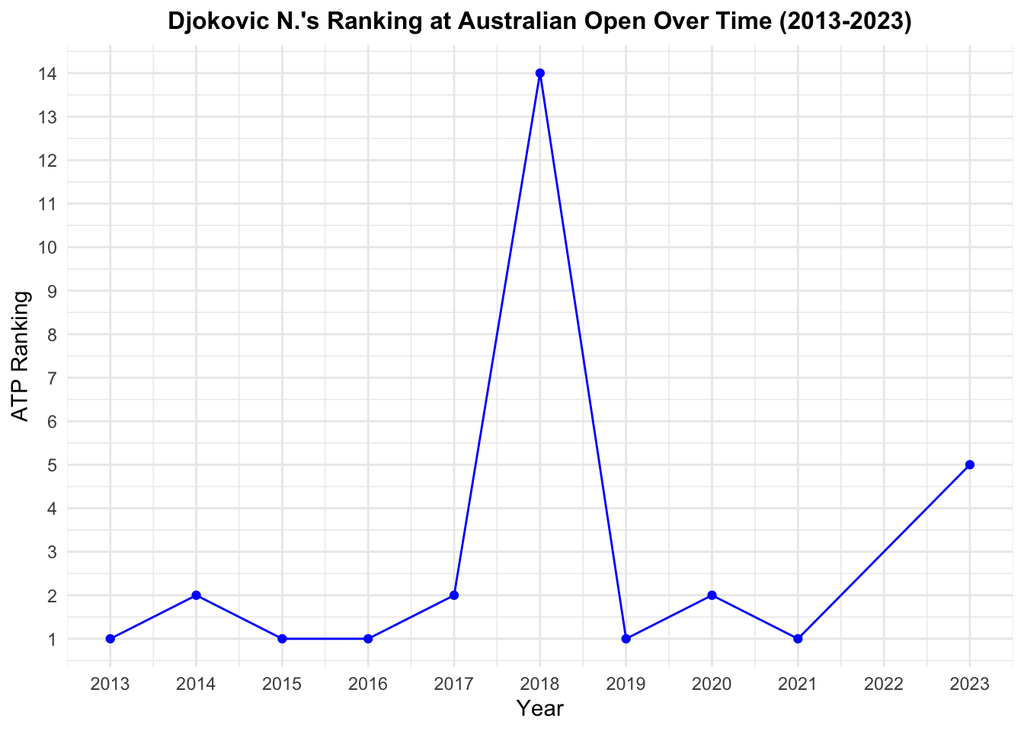

Observations vary depending on the player and tournament selected. For a consistently top-ranked player, such as Novak Djokovic at the Australian Open, the line plot would show a generally stable ranking within the top positions, often near the top ranks, with minor fluctuations reflecting injuries or poor performance in past seasons. In contrast, a mid-ranked player like John Isner at Wimbledon might exhibit more fluctuations, highlighting inconsistency or improvement over time. For an emerging player, such as Carlos Alcaraz in his early years, the plot could reveal a sharp upward trend, with rankings improving significantly, showcasing the player’s development.

Coaches can use this data to identify patterns and trends in a player’s performance at that tournament, allowing them to tailor training and preparation strategies accordingly. For instance, if a player’s ranking shows significant improvement in certain years, coaches can analyze the factors that contributed to these successes and seek to replicate them. Conversely, if the rankings indicate periods of decline, coaches can investigate potential issues such as injuries, strategic missteps, or mental factors that might have impacted performance.

Players can also benefit from this analysis by gaining a clearer understanding of their historical performance at a specific tournament. This knowledge can boost their confidence if the trend shows improvement or consistent high rankings. It can also help them set realistic goals and focus on specific areas for improvement if the data reveals a pattern of poor performance. By reflecting on their past rankings, players can develop a more informed approach to their preparation, both mentally and physically, for future iterations of the tournament.

### Chart 3 - Tournament Title Wins by Player

A standard bar graph for visualizing the number of tournament wins at a specific tournament between three given players at a time was the most suitable chart type for several reasons. For one, bar graphs are highly effective for comparing discrete categories, making them ideal for showcasing the number of wins each player has achieved. By representing each player with a separate bar, the graph allows for easy visual comparison of their performance.

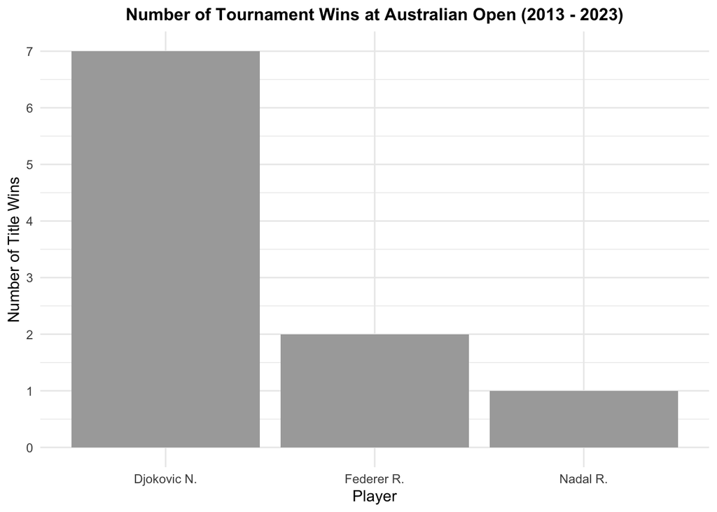

A standard bar chart depicting the number of tournament wins at a specific tournament for three players like the Big Three—Novak Djokovic, Roger Federer, and Rafael Nadal—reveals varying insights depending on the tournament selected. In the case of the Australian Open from 2013 to 2023, the chart shows that Djokovic clearly dominates, with seven title wins, compared to Federer’s two and Nadal’s one. This highlights Djokovic’s exceptional performance and consistency at the Australian Open, positioning him as the most successful player at this tournament during the specified period and players chosen to examine.

However, if the chart were to focus on the French Open instead, the narrative would shift dramatically. Rafael Nadal’s dominance on clay courts would be unmistakable, with a significantly higher number of title wins compared to Djokovic and Federer. Such a chart would emphasize Nadal’s unparalleled success at the French Open, where he has been the dominant titleholder for more than a decade, highlighting his dominance on this surface.

Insights derived from this bar chart can be valuable for players and coaches. Understanding which tournaments a player excels at can help tailor training regimens specific to those events. For Djokovic, the data reinforces his stronghold on the Australian Open, suggesting that his preparation strategies and playing style are well-suited to the conditions in Melbourne. For Nadal, a similar chart for the French Open would highlight the importance of his clay-court training.

Additionally, for coaches, such a chart can inform decisions about tournament scheduling and focus areas for improvement. It can guide them in optimizing their player’s performance by replicating successful strategies from tournaments where they have historically excelled and addressing weaknesses evident from tournaments with fewer wins. Overall, this visual representation of tournament wins provides a clear, comparative insight into each player’s dominance at specific events, offering a strategic tool for enhancing future performances.